# Ciencia de Datos

#### Chernoff’s faces: Muestra todas las variables como caracterı́sticas de rostros. Cada variable corresponde a la forma y tamaño de alguna caracterı́stica de la cara.

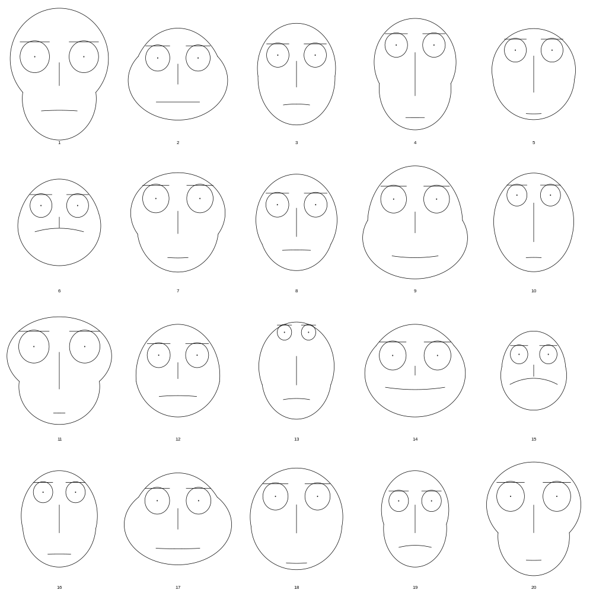

```python
from IPython.display import Image
Image(filename='../figs/chernoff1.png',width=600)
```

effect of variables:

"People grow up studying and reacting to faces all of the time. Small and barely measurable differences are easily detected and evoke emotional reactions from a long catalogue buried in the memory... This implies that the human mind subconsciously operates as a high-speed computer, filtering out insignificant visual phenomena and focusing on the potentially important.”

Herman Chernoff (1973). *“The Use of Faces to Represent Points in K-Dimensional Space Graphically”*. Journal of the American Statistical Association. American Statistical Association. 68 (342): 361–368.